# Problem Set 7 S520

Aakash Ahuja

10/25/2019

**Question1: Suppose that I toss a fair coin 100 times and observe 60 Heads. Now I decide to toss the same coin another 100 times. Does the Law of Averages imply that I should expect to observe another 40 Heads?**

Answer1: Let’s try to do this experiment on R and see if this holds.

```r
sample1<-sample(c(0,1),100, replace = T)
samplemean<-mean(sample1)
samplemean
```

```
## [1] 0.58
```

```r
sample2<-sample(c(0,1),100, replace = T)
samplemean2<-mean(sample2)
samplemean2
```

```
## [1] 0.46
```

If I toss a fair coin 100 times and observe 60 heads, the law of averages **does not** imply that if I toss the coin again 100 times, I should expect to observe another 40 heads to average it out. As we start with a fair coin, the law of averages says that the expected number of heads is 50 in the next 100 toss of coins independent of the previous tosses.

**Question5: As part of the 2016 American National Election Studies (ANES) pilot study conducted in January 2016, a sample of 1200 respondents were asked to rate various public figures on a ‘feeling thermometer’ from 0 to 100, where 0 indicates ‘very cold’ and 100 indicates ‘very warm’ feelings toward the figure. The file ANES2016.txt contains the feeling thermometer scores for three Presidential candidates: Donald Trump, Hillary Clinton, and Bernie Sanders. (The full data set for the study is in anes pilot 2016.csv, but you do not have to use it here.) To simplify things, assume the respondents are a simple random sample from the population of adult U.S. citizens (this is not quite true but is close enough for our purposes.)**

**a)Draw side-by-side boxplots (on the same plot) of the feeling thermometer scores for Trump, Clinton, and Sanders. What???s wrong with the data?**

Answer a):

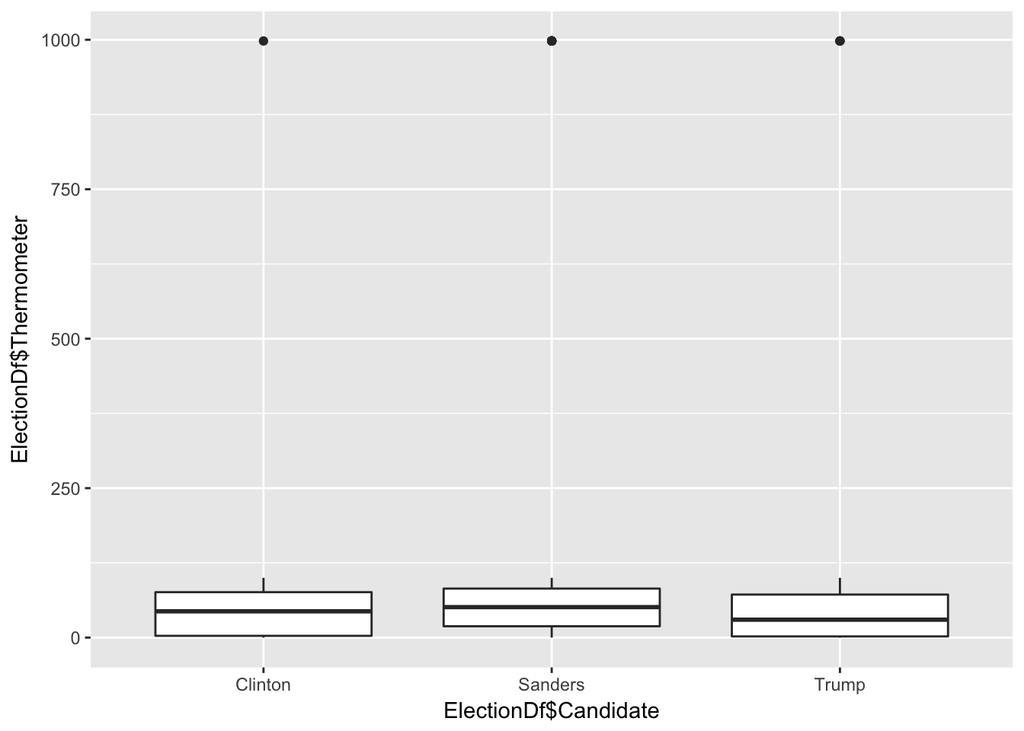

```r
ElectionDf<-read.table("ANES2016.txt",header=TRUE)
library(ggplot2)
ggplot(ElectionDf, aes(x= ElectionDf$Candidate, y=ElectionDf$Thermometer)) + geom_boxplot()
```

**It’s clear what is unusual in these 3 boxplots. There are 3 outlier thermometer scores for all the three candidates which lie outside the range of 0 to 100(the given range of thermometer scores)**

**b)Get rid of the feeling thermometer observations that are greater than 100, e.g. by using the subset() function. Find the sample mean and sample standard deviation for the new variables for Trump, Clinton, and Sanders.**

```r
#Getting Rid of observations greater than 100
ElectionDfSubset<-subset(ElectionDf,ElectionDf$Thermometer<=100)

#Calculating mean for each of the 3 candidates
mean_by_category<-aggregate(Thermometer~Candidate,ElectionDfSubset,mean)
mean_by_category
```

```
##   Candidate Thermometer
## 1   Clinton    42.99416
## 2   Sanders    50.41191
## 3     Trump    38.37845
```

```r
#Calculating Standard Deviation for each of the 3 candidates
sd_by_category<-aggregate(Thermometer~Candidate,ElectionDfSubset,sd)
sd_by_category
```

```
##   Candidate Thermometer
## 1   Clinton    36.50470
## 2   Sanders    33.39091
## 3     Trump    36.52897
```

**c)Find 99% confidence intervals for:**

**i. Trump’s mean feeling thermometer score if all adult U.S. citizens were asked in January 2016.**

**ii. Clinton’s mean feeling thermometer score if all adult U.S. citizens were asked in January 2016.**

**iii. Sanders’ mean feeling thermometer score if all adult U.S. citizens were asked in January 2016.**

```r
Trump_mean<-mean_by_category[mean_by_category$Candidate=='Trump',2]
Trump_sd<-sd_by_category[sd_by_category$Candidate=='Trump',2]
#99% Confidence Interval for Trump's mean feeling
CI_Trump<-c(Trump_mean-qnorm(1-.005)*Trump_sd /sqrt(nrow(ElectionDfSubset[ElectionDfSubset$Candidate=="Trump",])),Trump_mean+qnorm(1-.005)*Trump_sd /sqrt(nrow(ElectionDfSubset[ElectionDfSubset$Candidate=="Trump",])))
CI_Trump
```

```
## [1] 35.65883 41.09806
```

```r
#99% Confidence Interval for Clinton's mean feeling
Clinton_mean<-mean_by_category[mean_by_category$Candidate=='Clinton',2]
Clinton_sd<-sd_by_category[sd_by_category$Candidate=='Clinton',2]
CI_Clinton<-c(Clinton_mean-qnorm(1-.005)*Clinton_sd /sqrt(nrow(ElectionDfSubset[ElectionDfSubset$Candidate=="Clinton",])),Clinton_mean+qnorm(1-.005)*Clinton_sd /sqrt(nrow(ElectionDfSubset[ElectionDfSubset$Candidate=="Clinton",])))
CI_Clinton
```

```
## [1] 40.27862 45.70970
```

```r
#99% Confidence Interval for Sanders's mean feeling
Sanders_mean<-mean_by_category[mean_by_category$Candidate=='Sanders',2]
Sanders_sd<-sd_by_category[sd_by_category$Candidate=='Sanders',2]
CI_Sanders<-c(Sanders_mean-qnorm(1-.005)*Sanders_sd /sqrt(nrow(ElectionDfSubset[ElectionDfSubset$Candidate=="Sanders",])),Sanders_mean+qnorm(1-.005)*Sanders_sd /sqrt(nrow(ElectionDfSubset[ElectionDfSubset$Candidate=="Sanders",])))
CI_Sanders
```

```
## [1] 47.92072 52.90310
```